# Medical Insurance Charges - GLM Final Project

Jacob Gigliotti

2025-12-9

## Final Project

```r
data <- read.csv("FPD.CSV")

# Set categorical variables as factors
data$sex    <- factor(data$sex)
data$smoker <- factor(data$smoker)
data$region <- factor(data$region)

str(data)
```

```
## 'data.frame':    2772 obs. of  7 variables:
##  $ age     : int  19 18 28 33 32 31 46 37 37 60 ...
##  $ sex     : Factor w/ 2 levels "female","male": 1 2 2 2 2 1 1 1 2 1 ...
##  $ bmi     : num  27.9 33.8 33 22.7 28.9 ...
##  $ children: int  0 1 3 0 0 0 1 3 2 0 ...
##  $ smoker  : Factor w/ 2 levels "no","yes": 2 1 1 1 1 1 1 1 1 1 ...
##  $ region  : Factor w/ 4 levels "northeast","northwest",..: 4 3 3 2 2 3 3 2 1 2 ...
##  $ charges : num  16885 1726 4449 21984 3867 ...
```

```r
summary(data)
```

```
##       age            sex            bmi           children     smoker
##  Min.   :18.00   female:1366   Min.   :15.96   Min.   :0.000   no :2208
##  1st Qu.:26.00   male  :1406   1st Qu.:26.22   1st Qu.:0.000   yes: 564
##  Median :39.00                 Median :30.45   Median :1.000
##  Mean   :39.11                 Mean   :30.70   Mean   :1.102
##  3rd Qu.:51.00                 3rd Qu.:34.77   3rd Qu.:2.000
##  Max.   :64.00                 Max.   :53.13   Max.   :5.000
##        region       charges
##  northeast:658   Min.   : 1122
##  northwest:664   1st Qu.: 4688
##  southeast:766   Median : 9333
##  southwest:684   Mean   :13261
##                  3rd Qu.:16578
##                  Max.   :63770
```

```r
library(tidyverse)
library(MASS)
library(lmtest)
```

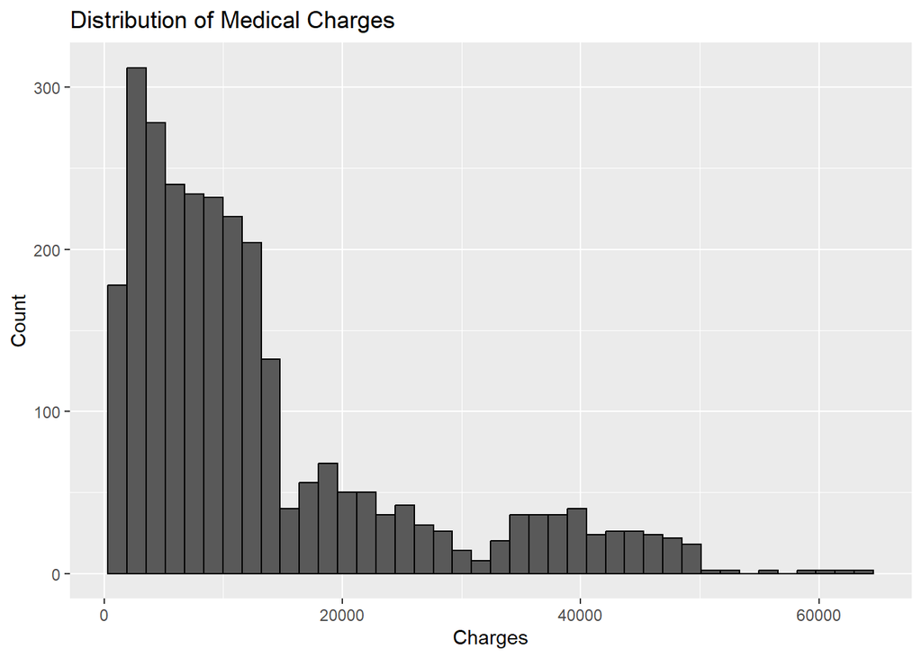

```r
library(ggplot2)

# Histogram of charges to justify Gamma GLM
ggplot(data, aes(x = charges)) +
  geom_histogram(bins = 40, color = "black") +
  labs(title = "Distribution of Medical Charges", x = "Charges", y = "Count")
```

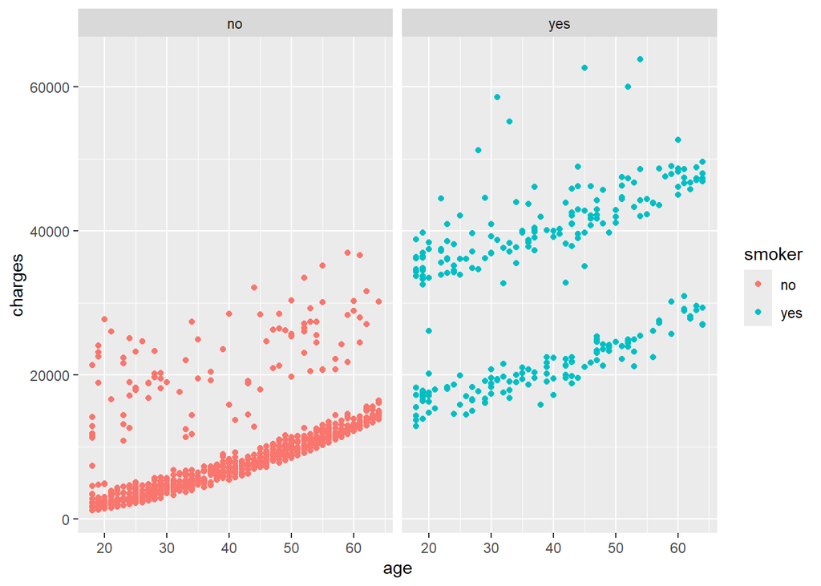

```r
# 2. Data Patterns: charges vs X
library(tidyverse)

# Charges vs age by smoker
ggplot(data, aes(x = age, y = charges, color = smoker)) +
  geom_point() +
  facet_wrap(~smoker, nrow = 1)
```

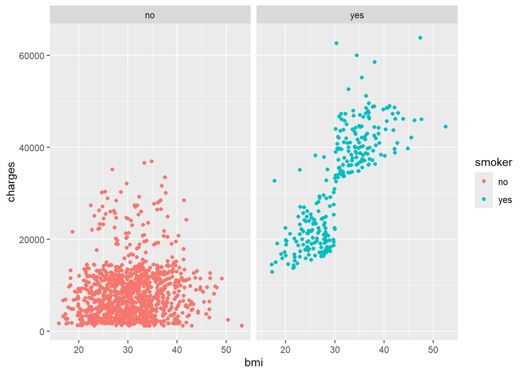

```r
# Charges vs BMI by smoker
ggplot(data, aes(x = bmi, y = charges, color = smoker)) +
  geom_point() +
  facet_wrap(~smoker, nrow = 1)
```

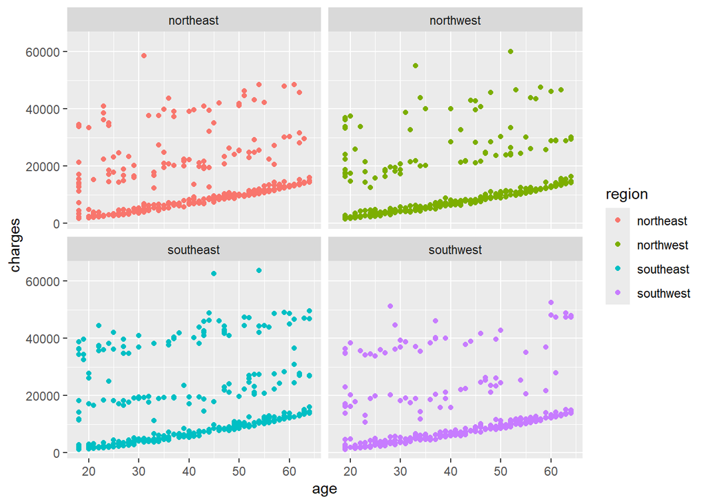

```r
# Charges vs age by region
ggplot(data, aes(x = age, y = charges, color = region)) +
  geom_point() +
  facet_wrap(~region, nrow = 2)
```

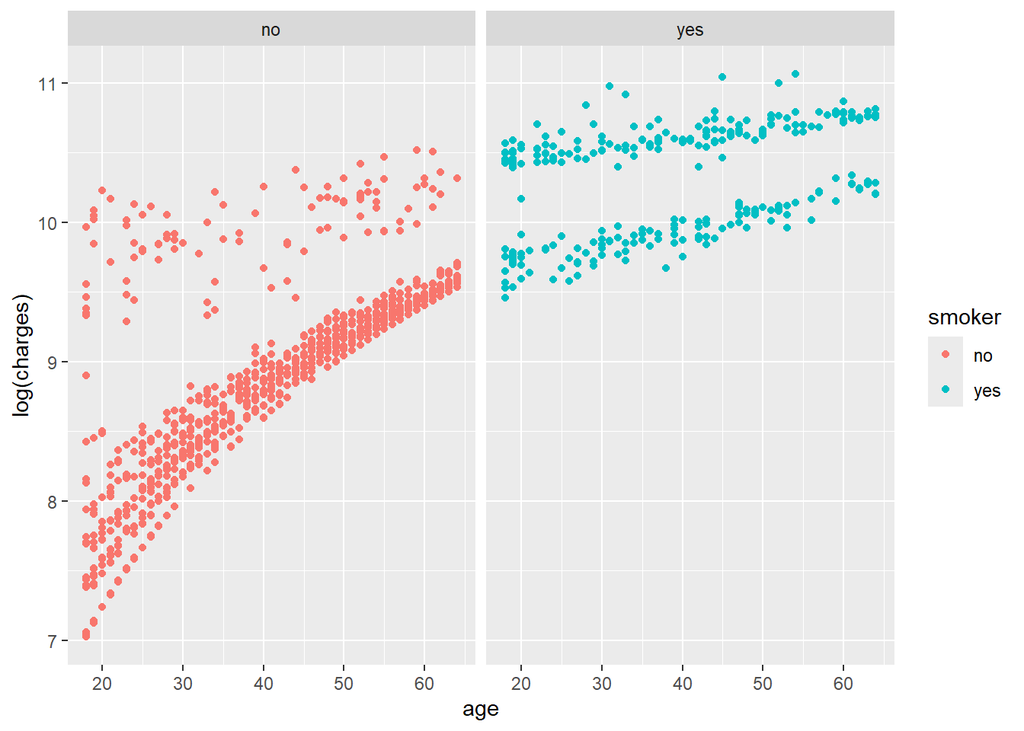

```r
# 3. Determine Link Function


# Try log(charges) vs numerical X’s within categories to justify log link
ggplot(data, aes(x = age, y = log(charges), color = smoker)) +
  geom_point() +
  facet_wrap(~smoker, nrow = 1)
```

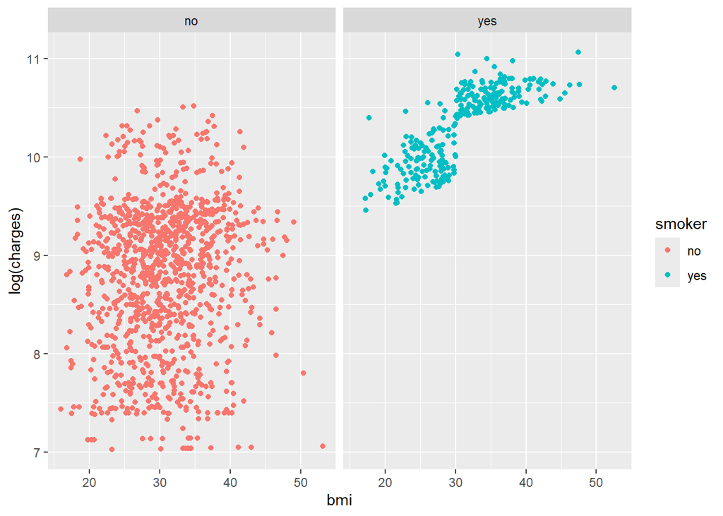

```r
ggplot(data, aes(x = bmi, y = log(charges), color = smoker)) +
  geom_point() +
  facet_wrap(~smoker, nrow = 1)
```

```r
# If relationships look roughly linear on log scale → choose link = "log".
```

```r
data1 <- data
colnames(data1)[which(names(data1) == "charges")] <- "y"

library(bestglm)
result <- bestglm(Xy = data1,
                  family = Gamma(link = "log"),
                  IC = "AIC")
```

```
## Morgan-Tatar search since family is non-gaussian.
```

```
## Note: factors present with more than 2 levels.
```

```r
result$BestModels
```

```
##    age   sex   bmi children smoker region Criterion
## 1 TRUE  TRUE  TRUE     TRUE   TRUE   TRUE  54664.02
## 2 TRUE FALSE  TRUE     TRUE   TRUE   TRUE  54670.05
## 3 TRUE  TRUE  TRUE     TRUE   TRUE  FALSE  54709.09
## 4 TRUE FALSE  TRUE     TRUE   TRUE  FALSE  54714.81
## 5 TRUE  TRUE FALSE     TRUE   TRUE   TRUE  54725.62
```

```r
library(lmtest)

# Main-effects model (like mod0 in Note33)
mod0 <- glm(charges ~ age + bmi + children + sex + smoker + region,
            family = Gamma(link = "log"),
            data = data)

# Try interaction: smoker:bmi
mod1 <- glm(charges ~ age + bmi + children + sex + region +
              smoker * bmi,
            family = Gamma(link = "log"),
            data = data)

lrtest(mod0, mod1)
```

```
## Likelihood ratio test
##
## Model 1: charges ~ age + bmi + children + sex + smoker + region
## Model 2: charges ~ age + bmi + children + sex + region + smoker * bmi
##   #Df LogLik Df  Chisq Pr(>Chisq)
## 1  10 -27324
## 2  11 -27247  1 155.04  < 2.2e-16 ***
## ---
## Signif. codes:  0 '***' 0.001 '**' 0.01 '*' 0.05 '.' 0.1 ' ' 1
```

```r
# If p-value is large → interaction not needed.

# Try interaction: age:bmi
mod2 <- glm(charges ~ age * bmi + children + sex + smoker + region,
            family = Gamma(link = "log"),
            data = data)

lrtest(mod0, mod2)
```

```
## Likelihood ratio test
##
## Model 1: charges ~ age + bmi + children + sex + smoker + region
## Model 2: charges ~ age * bmi + children + sex + smoker + region
##   #Df LogLik Df  Chisq Pr(>Chisq)
## 1  10 -27324
## 2  11 -27319  1 9.6959   0.001847 **
## ---
## Signif. codes:  0 '***' 0.001 '**' 0.01 '*' 0.05 '.' 0.1 ' ' 1
```

```r
# Again, keep only if LR test p-value < 0.05.

# Assume best model is mod0 (no interactions), like in the note
best_mod <- mod0
```

```r
mod0 <- glm(charges ~ age + bmi + children + sex + smoker + region,
            family = Gamma(link = "log"),
            data = data)

summary(mod0)
```

```
##
## Call:
## glm(formula = charges ~ age + bmi + children + sex + smoker +
##     region, family = Gamma(link = "log"), data = data)
##
## Coefficients:
##                   Estimate Std. Error t value Pr(>|t|)
## (Intercept)      7.4173598  0.0783367  94.686  < 2e-16 ***
## age              0.0285307  0.0009429  30.259  < 2e-16 ***
## bmi              0.0133262  0.0022660   5.881 4.57e-09 ***
## children         0.0839753  0.0108531   7.737 1.41e-14 ***
## sexmale         -0.0539258  0.0264435  -2.039   0.0415 *
## smokeryes        1.5068530  0.0328980  45.804  < 2e-16 ***
## regionnorthwest -0.0387139  0.0381348  -1.015   0.3101
## regionsoutheast -0.1560887  0.0381391  -4.093 4.39e-05 ***
## regionsouthwest -0.1563129  0.0379913  -4.114 3.99e-05 ***
## ---
## Signif. codes:  0 '***' 0.001 '**' 0.01 '*' 0.05 '.' 0.1 ' ' 1
##
## (Dispersion parameter for Gamma family taken to be 0.4797485)
##
##     Null deviance: 2209.47  on 2771  degrees of freedom
## Residual deviance:  715.28  on 2763  degrees of freedom
## AIC: 54668
##
## Number of Fisher Scoring iterations: 7
```

```r
library(lmtest)

mod1 <- glm(charges ~ age + bmi + children + sex + region + smoker*bmi,
            family = Gamma(link="log"), data=data)

lrtest(mod0, mod1)     # Keep interaction only if p < 0.05
```

```
## Likelihood ratio test
##
## Model 1: charges ~ age + bmi + children + sex + smoker + region
## Model 2: charges ~ age + bmi + children + sex + region + smoker * bmi
##   #Df LogLik Df  Chisq Pr(>Chisq)
## 1  10 -27324
## 2  11 -27247  1 155.04  < 2.2e-16 ***
## ---
## Signif. codes:  0 '***' 0.001 '**' 0.01 '*' 0.05 '.' 0.1 ' ' 1
```

```r
mod2 <- glm(charges ~ age + bmi + children + sex + region + smoker*age,
            family = Gamma(link="log"), data=data)

lrtest(mod0, mod2)
```

```
## Likelihood ratio test
##
## Model 1: charges ~ age + bmi + children + sex + smoker + region
## Model 2: charges ~ age + bmi + children + sex + region + smoker * age
##   #Df LogLik Df  Chisq Pr(>Chisq)
## 1  10 -27324
## 2  11 -27209  1 230.86  < 2.2e-16 ***
## ---
## Signif. codes:  0 '***' 0.001 '**' 0.01 '*' 0.05 '.' 0.1 ' ' 1
```

```r
mod3 <- glm(charges ~ age + bmi + children + sex + smoker + region*bmi,
            family = Gamma(link="log"), data=data)

lrtest(mod0, mod3)
```

```
## Likelihood ratio test
##
## Model 1: charges ~ age + bmi + children + sex + smoker + region
## Model 2: charges ~ age + bmi + children + sex + smoker + region * bmi
##   #Df LogLik Df  Chisq Pr(>Chisq)
## 1  10 -27324
## 2  13 -27318  3 12.633   0.005503 **
## ---
## Signif. codes:  0 '***' 0.001 '**' 0.01 '*' 0.05 '.' 0.1 ' ' 1
```

```r
mod4 <- glm(charges ~ age + bmi + children + smoker + region + sex*bmi,
            family = Gamma(link="log"), data=data)

lrtest(mod0, mod4)
```

```
## Likelihood ratio test
##
## Model 1: charges ~ age + bmi + children + sex + smoker + region
## Model 2: charges ~ age + bmi + children + smoker + region + sex * bmi
##   #Df LogLik Df  Chisq Pr(>Chisq)
## 1  10 -27324
## 2  11 -27323  1 1.2745     0.2589
```

```r
final_mod <- glm(
  charges ~ age + bmi + children + sex + smoker + region +
            smoker*bmi + smoker*age + region*bmi,
  family = Gamma(link = "log"),
  data = data
)
lrtest(mod0, final_mod)
```

```
## Likelihood ratio test
##
## Model 1: charges ~ age + bmi + children + sex + smoker + region
## Model 2: charges ~ age + bmi + children + sex + smoker + region + smoker *
##     bmi + smoker * age + region * bmi
##   #Df LogLik Df Chisq Pr(>Chisq)
## 1  10 -27324
## 2  15 -27100  5 448.6  < 2.2e-16 ***
## ---
## Signif. codes:  0 '***' 0.001 '**' 0.01 '*' 0.05 '.' 0.1 ' ' 1
```

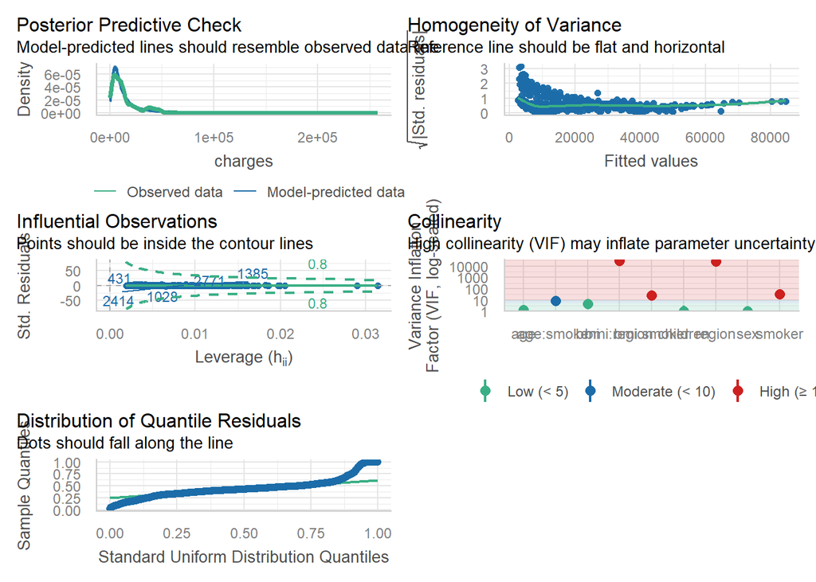

```r
library(performance)
check_model(final_mod)
```

```r
summary(final_mod)
```

```
##
## Call:
## glm(formula = charges ~ age + bmi + children + sex + smoker +
##     region + smoker * bmi + smoker * age + region * bmi, family = Gamma(link = "log"),
##     data = data)
##
## Coefficients:
##                      Estimate Std. Error t value Pr(>|t|)
## (Intercept)          7.253882   0.148476  48.855  < 2e-16 ***
## age                  0.034176   0.001073  31.858  < 2e-16 ***
## bmi                  0.011850   0.004815   2.461 0.013912 *
## children             0.092696   0.011020   8.411  < 2e-16 ***
## sexmale             -0.063592   0.026906  -2.363 0.018173 *
## smokeryes            0.863301   0.185599   4.651 3.45e-06 ***
## regionnorthwest      0.295059   0.209288   1.410 0.158704
## regionsoutheast      0.484734   0.192245   2.521 0.011744 *
## regionsouthwest      0.008215   0.202575   0.041 0.967654
## bmi:smokeryes        0.052382   0.005363   9.766  < 2e-16 ***
## age:smokeryes       -0.026641   0.002388 -11.157  < 2e-16 ***
## bmi:regionnorthwest -0.011574   0.007055  -1.641 0.100986
## bmi:regionsoutheast -0.020601   0.006079  -3.389 0.000712 ***
## bmi:regionsouthwest -0.006734   0.006651  -1.013 0.311387
## ---
## Signif. codes:  0 '***' 0.001 '**' 0.01 '*' 0.05 '.' 0.1 ' ' 1
##
## (Dispersion parameter for Gamma family taken to be 0.4934373)
##
##     Null deviance: 2209.47  on 2771  degrees of freedom
## Residual deviance:  612.17  on 2758  degrees of freedom
## AIC: 54229
##
## Number of Fisher Scoring iterations: 6
```

```r
confint(final_mod, level = 0.95)
```

```
##                            2.5 %       97.5 %
## (Intercept)          6.956010669  7.553340032
## age                  0.032063976  0.036289004
## bmi                  0.002236536  0.021505058
## children             0.070687169  0.114883337
## sexmale             -0.116497857 -0.010694791
## smokeryes            0.491681032  1.237394677
## regionnorthwest     -0.112895044  0.703811363
## regionsoutheast      0.098597045  0.870818812
## regionsouthwest     -0.405856033  0.422584468
## bmi:smokeryes        0.041577630  0.063190053
## age:smokeryes       -0.031286121 -0.021984259
## bmi:regionnorthwest -0.025347421  0.002177034
## bmi:regionsoutheast -0.032825936 -0.008388252
## bmi:regionsouthwest -0.020348592  0.006876612
```

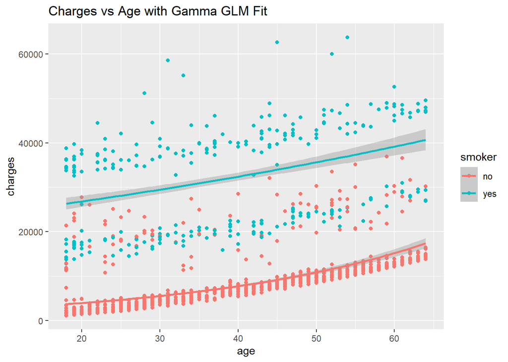

```r
# Charges vs age with Gamma GLM smooth
ggplot(data, aes(x = age, y = charges, color = smoker)) +
  geom_point() +
  geom_smooth(method = "glm",
              method.args = list(family = Gamma(link = "log")),
              se = TRUE) +
  labs(title = "Charges vs Age with Gamma GLM Fit")
```

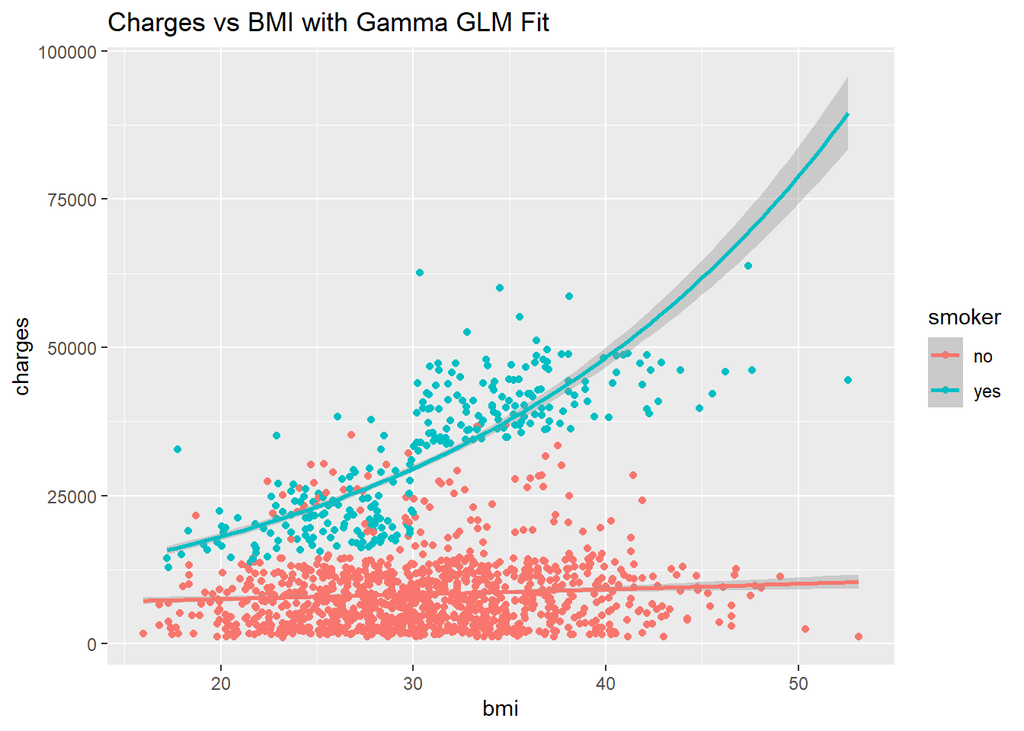

```r
# Charges vs BMI with Gamma GLM smooth
ggplot(data, aes(x = bmi, y = charges, color = smoker)) +
  geom_point() +
  geom_smooth(method = "glm",
              method.args = list(family = Gamma(link = "log")),
              se = TRUE) +
  labs(title = "Charges vs BMI with Gamma GLM Fit")
```

```r
# Predict charges for a specific profile
newdata <- data.frame(
  age      = 40,
  bmi      = 30,
  children = 1,
  sex      = factor("male", levels = levels(data$sex)),
  smoker   = factor("no",   levels = levels(data$smoker)),
  region   = factor("southeast", levels = levels(data$region))
)
pred <- predict(best_mod, newdata, type = "response")
pred
```

```
##       1
## 6852.26
```

```r
predict(final_mod, newdata = data.frame(age = 40, bmi = 30, children = 1,
                                        sex = "male", smoker = "yes",
                                        region = "southeast"), type = "response")
```

```
##        1
## 28039.68
```

```r
predict(final_mod, newdata = data.frame(age = 20, bmi = 22, children = 0,
                                        sex = "female", smoker = "no",
                                        region = "northeast"), type = "response")
```

```
##        1
## 3634.081
```

```r
predict(final_mod, newdata = data.frame(age = 60, bmi = 30, children = 1,
                                        sex = "male", smoker = "yes",
                                        region = "southeast"), type = "response")
```

```
##        1
## 32600.46
```

# Report

## 1. Introduction

Healthcare costs in the United States vary across individuals, this is driven by demographic characteristics, health behaviors, as well as regional factors. Understanding the determinants of medical insurance charges is important for insurers, policymakers, and individuals, as it helps with pricing, risk assessment, and evaluating which insurance plan is needed for an individual.

The purpose of this study is to model annual medical insurance charges using individual demographic and health-related variables. Since medical charges and the data points are strictly positive and highly right-skewed, linear regressions were not needed. Instead, this study applies a Gamma GLM with a log link to better present the distributional properties of medical costs. This analysis examines how age, BMI, number of children, sex, smoking status, and geographic region influence the expected medical charges of an individual, while also allowing for interaction effects where relationships differ across subgroups.

## 2. Data Description

The dataset used in this study is from a widely used medical insurance dataset containing 2,772 observations and 7 variables. Each observation corresponds to an insurance policyholder.

### Response Variable

- **Charges**: The y variable in this dataset is annual medical insurance charges for an individual. This variable is continuous, strictly positive, and exhibits a heavy right tail, with values ranging from approximately $1,122 to over $63,000.

### Predictor Variables

- **Age**: Age of the policyholder, ranging from 18-64 years old.
- **BMI**: Body Mass Index, a measure of body fat based on height and weight.
- **Children**: Number of dependents covered by the insurance plan.
- **Sex**: Female or male.
- **Smoker**: Indicator of whether the individual is a smoker
- **Region**: Geographic region of policyholder

The summary shows that the average age is about 39 years, the average BMI is approximately 30.7, and the average annual medical charge is around $13,261. Most individuals are non-smokers, but smokers account for a large amount of the high-cost policyholders.

Initial data visualizations show that medical charges increase with age and BMI, particularly among smokers. Smokers consistently exhibit higher medical costs than non-smokers. These patterns suggest potential interaction effects between smoking status and other predictors.

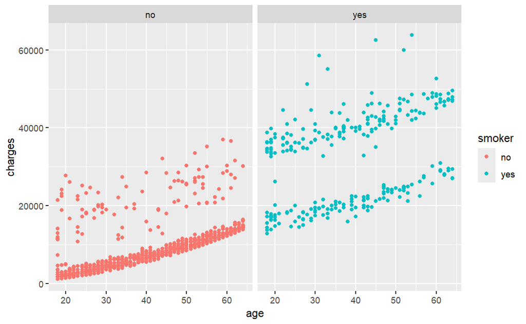

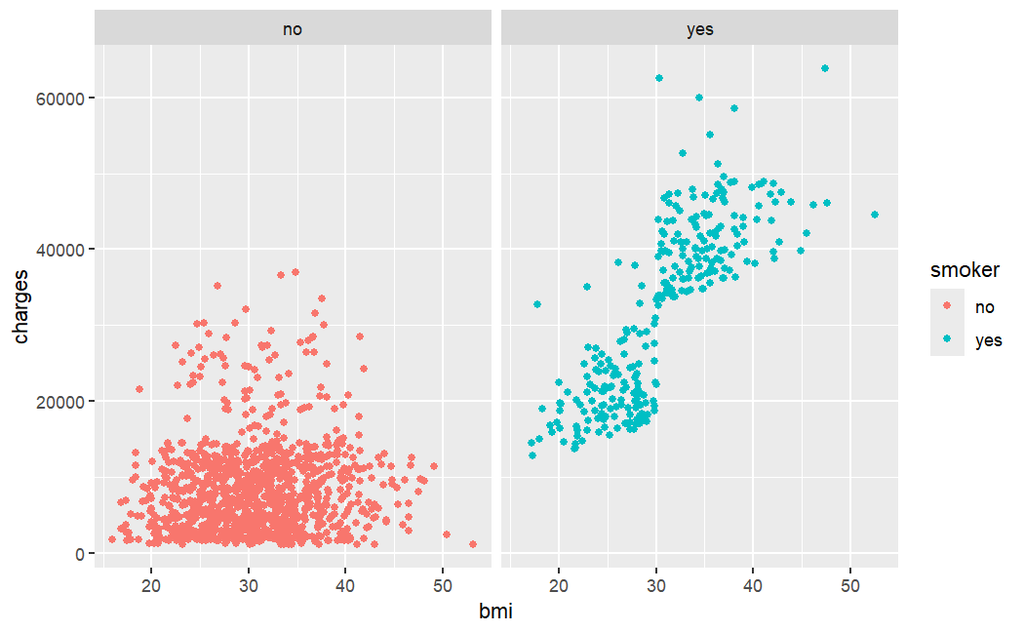

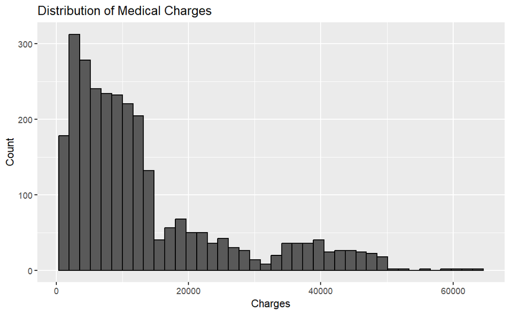

### 3. Model and Method Selection

Standard Ordinary Least Squaresregression needs a normal distribution and constant variance. Because medical charges are strictly positive and heavily skewed, a Gamma GLM with a log link was selected.

- **Gamma Distribution**: Designed for continuous, positive data where the variance increases with the mean, which is a very typical of insurance data.
- **Log Link Function**: Ensures all predicted values are positive

Model Selection Process:

AIC selection showed that all six predictors were relevant. However, the Likelihood Ratio Tests were used to confirm the necessity of interaction terms. Tests for smoker*bmi and smoker*age returned p-values near zero justifying a complex model that accounts for compounding risks.

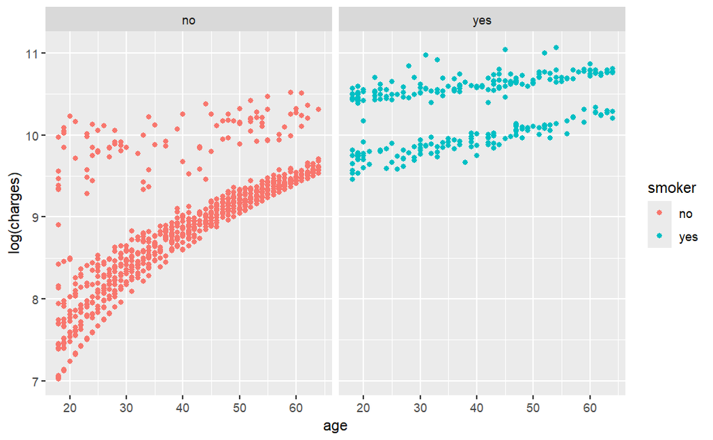

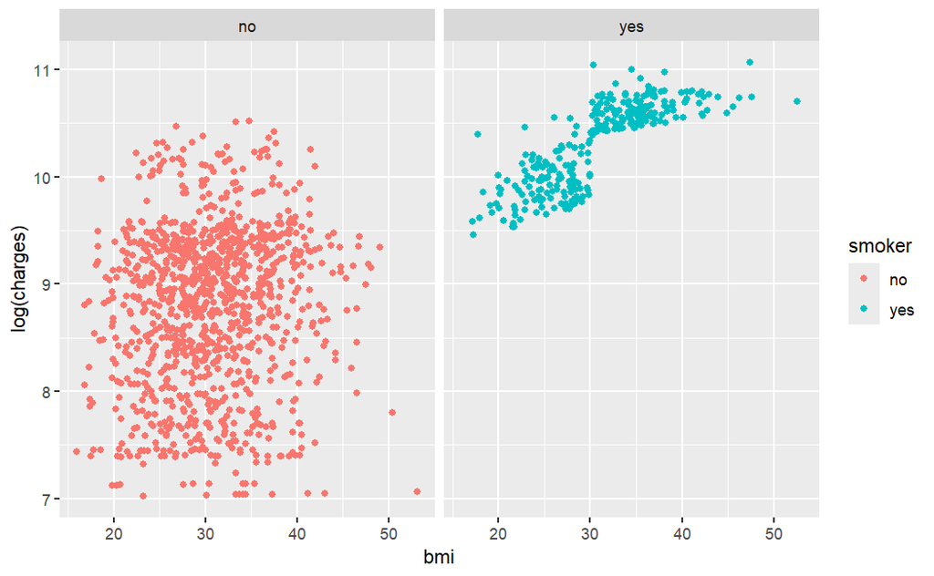

### 4.Model Assumption Checking

Before finalizing the inferences, the model was validated using the check model function:

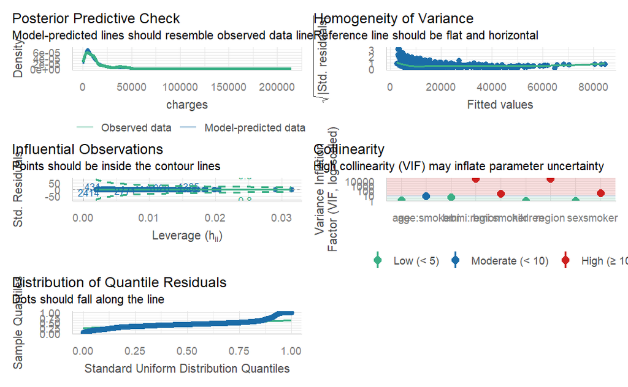

### 5. Inference and Analysis

The final model reveals that medical insurance risk is multiplicative rather than additive. So for a traditional additive model, each risk factor would add a fixed dollar amount to the individual charge. However, this Gamma model indicates that risks multiply each other. This means that the presence of one factor can actually makes every other factor more expensive.

Because the model uses a log link, every coefficient represents a percentage increase rather than a flat fee. for example, the cost of getting older is not constant; it compounds based on the existing health profile of the policyholder. As the base bill grows larger due to factors like BMI or smoking, every other percentage-based for each increase for each factor becomes significantly more expensive.

#### The Smoking Multiplier

The most dominant finding of this analysis is that smoking is the biggest facotr for the cost.

#### Compounding BMI Risk

Another finding is that between the interaction between smoking and BMI. The data proves that the financial impact of a high BMI is not the same for everyone, but it is significantly amplified for smokers.

- For those who do not smoke, the cost increase associated with gaining weight is steady.
- For smokers, the interaction effect shows that the cost increases as BMI increases.

This interaction demonstrates that the smoking status makes the body much more sensitive to the costs of weight gain.

#### Other Effects

The multiplicative nature of the model also applies to demographic variables.

- **Regional Variation**: The model also found that region interacts with BMI. This shows that the cost of weight-related health issues may vary depending on the local healthcare infrastructure, regional health trends, or cost of living in different parts of the country.

Ultimately, the inference of this model is that medical costs do not grow in a straight line. The more risk factors a person has, the more those factors multiply the total financial cost for their healthcare plan.

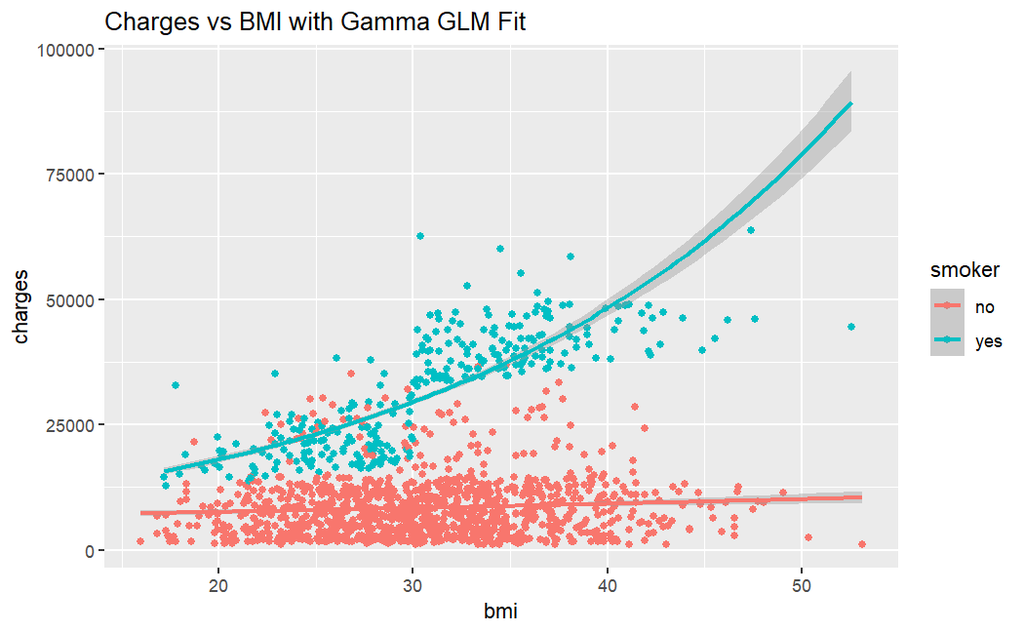

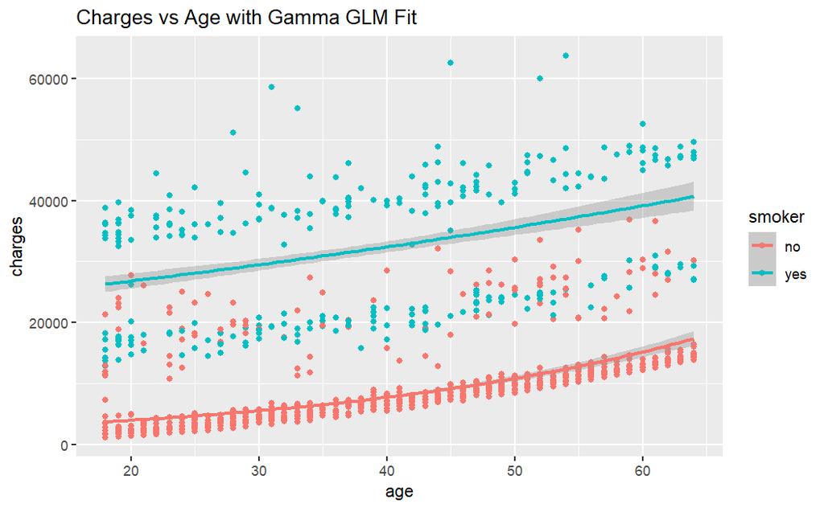

### 6. Prediction

#### Comparison of Risk Scenarios

The most dramatic change occurs when smoking is introduced. A High-Risk Adult with the exact same age and BMI as the average adult, but who smokes, jumps to a predicted cost of $28,039 . Finally, an Extreme Risk individual (60 years old, smoker, BMI of 30) reaches a predicted annual cost of $32,600 .